# NYC Green Taxi Sept 2015: Analysis

C949621

January 5, 2019

## Green Taxis

Green Taxis or as they are popularly known, **Boro taxis** (or Boro cabs) are cabs in New York city that pick up passengers from outer boroughs. There are 5 boroughs in New York City, namely, Manhattan, Brooklyn, Staten Island, Queens and Bronx. Green cabs can only pick up passengers from above East 69th and West 110th Streets in Manhattan and from other boroughs.

Following code programmatically downloads the data and will give number of rows, columns as the output

**Question 1**

```r
###########################################################################################
#Question 1
###########################################################################################

##if RCurl is not already installed, install using instal.packages('RCurl')

library(RCurl)
url <- "https://s3.amazonaws.com/nyc-tlc/trip+data/green_tripdata_2015-09.csv"
data <- read.csv(file = url)
dim(data)
```

```
## [1] 1494926      21
```

```r
#data will take some time to load. DO NOT terminate the code

names(data)
```

```
##  [1] "VendorID"              "lpep_pickup_datetime"
##  [3] "Lpep_dropoff_datetime" "Store_and_fwd_flag"
##  [5] "RateCodeID"            "Pickup_longitude"
##  [7] "Pickup_latitude"       "Dropoff_longitude"
##  [9] "Dropoff_latitude"      "Passenger_count"
## [11] "Trip_distance"         "Fare_amount"
## [13] "Extra"                 "MTA_tax"
## [15] "Tip_amount"            "Tolls_amount"
## [17] "Ehail_fee"             "improvement_surcharge"
## [19] "Total_amount"          "Payment_type"
## [21] "Trip_type"
```

```r
str(data)
```

```
## 'data.frame':    1494926 obs. of  21 variables:
##  $ VendorID             : int  2 2 2 2 2 2 2 2 2 2 ...
##  $ lpep_pickup_datetime : Factor w/ 1079075 levels "2015-09-01 00:00:00",..: 58 97 43 60 5 15 18 52 60 50 ...
##  $ Lpep_dropoff_datetime: Factor w/ 1077210 levels "2015-09-01 00:00:00",..: 3 6 6 22 5 11 14 12 27 28 ...
##  $ Store_and_fwd_flag   : Factor w/ 2 levels "N","Y": 1 1 1 1 1 1 1 1 1 1 ...
##  $ RateCodeID           : int  5 5 1 1 1 1 1 1 1 1 ...
##  $ Pickup_longitude     : num  -74 -74 -73.9 -73.9 -74 ...
##  $ Pickup_latitude      : num  40.7 40.9 40.8 40.8 40.7 ...
##  $ Dropoff_longitude    : num  -74 -74 -73.9 -73.9 -73.9 ...
##  $ Dropoff_latitude     : num  40.7 40.9 40.8 40.8 40.7 ...
##  $ Passenger_count      : int  1 1 1 1 1 1 1 1 1 1 ...
##  $ Trip_distance        : num  0 0 0.59 0.74 0.61 1.07 1.43 0.9 1.33 0.84 ...
##  $ Fare_amount          : num  7.8 45 4 5 5 5.5 6.5 5 6 5.5 ...
##  $ Extra                : num  0 0 0.5 0.5 0.5 0.5 0.5 0.5 0.5 0.5 ...
##  $ MTA_tax              : num  0 0 0.5 0.5 0.5 0.5 0.5 0.5 0.5 0.5 ...
##  $ Tip_amount           : num  1.95 0 0.5 0 0 1.36 0 0 1.46 0 ...
##  $ Tolls_amount         : num  0 0 0 0 0 0 0 0 0 0 ...
##  $ Ehail_fee            : logi  NA NA NA NA NA NA ...
##  $ improvement_surcharge: num  0 0 0.3 0.3 0.3 0.3 0.3 0.3 0.3 0.3 ...
##  $ Total_amount         : num  9.75 45 5.8 6.3 6.3 8.16 7.8 6.3 8.76 6.8 ...
##  $ Payment_type         : int  1 1 1 2 2 1 1 2 1 2 ...
##  $ Trip_type            : int  2 2 1 1 1 1 1 1 1 1 ...
```

```r
#Number of Rows: 1494926
#Number of Columns: 21
head(data)
```

```
##   VendorID lpep_pickup_datetime Lpep_dropoff_datetime Store_and_fwd_flag
## 1        2  2015-09-01 00:02:34   2015-09-01 00:02:38                  N
## 2        2  2015-09-01 00:04:20   2015-09-01 00:04:24                  N
## 3        2  2015-09-01 00:01:50   2015-09-01 00:04:24                  N
## 4        2  2015-09-01 00:02:36   2015-09-01 00:06:42                  N
## 5        2  2015-09-01 00:00:14   2015-09-01 00:04:20                  N
## 6        2  2015-09-01 00:00:39   2015-09-01 00:05:20                  N
##   RateCodeID Pickup_longitude Pickup_latitude Dropoff_longitude
## 1          5        -73.97948        40.68496         -73.97943
## 2          5        -74.01080        40.91222         -74.01078
## 3          1        -73.92141        40.76671         -73.91441
## 4          1        -73.92139        40.76668         -73.93143
## 5          1        -73.95548        40.71405         -73.94441
## 6          1        -73.94530        40.80819         -73.93767
##   Dropoff_latitude Passenger_count Trip_distance Fare_amount Extra MTA_tax
```

[output cut: 20 more lines]

**Question 2**

Histogram of the number of trip distance:

```r
###########################################################################################
#Question 2
###########################################################################################

data1<- subset(data, select = -c(Ehail_fee))
data1<- na.omit(data1)
any(is.na(data1))
```

```
## [1] FALSE
```

```r
#data1 does not have any NA values now
str(data1)
```

```
## 'data.frame':    1494922 obs. of  20 variables:
##  $ VendorID             : int  2 2 2 2 2 2 2 2 2 2 ...
##  $ lpep_pickup_datetime : Factor w/ 1079075 levels "2015-09-01 00:00:00",..: 58 97 43 60 5 15 18 52 60 50 ...
##  $ Lpep_dropoff_datetime: Factor w/ 1077210 levels "2015-09-01 00:00:00",..: 3 6 6 22 5 11 14 12 27 28 ...
##  $ Store_and_fwd_flag   : Factor w/ 2 levels "N","Y": 1 1 1 1 1 1 1 1 1 1 ...
##  $ RateCodeID           : int  5 5 1 1 1 1 1 1 1 1 ...
##  $ Pickup_longitude     : num  -74 -74 -73.9 -73.9 -74 ...
##  $ Pickup_latitude      : num  40.7 40.9 40.8 40.8 40.7 ...
##  $ Dropoff_longitude    : num  -74 -74 -73.9 -73.9 -73.9 ...
##  $ Dropoff_latitude     : num  40.7 40.9 40.8 40.8 40.7 ...
##  $ Passenger_count      : int  1 1 1 1 1 1 1 1 1 1 ...
##  $ Trip_distance        : num  0 0 0.59 0.74 0.61 1.07 1.43 0.9 1.33 0.84 ...
##  $ Fare_amount          : num  7.8 45 4 5 5 5.5 6.5 5 6 5.5 ...
##  $ Extra                : num  0 0 0.5 0.5 0.5 0.5 0.5 0.5 0.5 0.5 ...
##  $ MTA_tax              : num  0 0 0.5 0.5 0.5 0.5 0.5 0.5 0.5 0.5 ...
##  $ Tip_amount           : num  1.95 0 0.5 0 0 1.36 0 0 1.46 0 ...
##  $ Tolls_amount         : num  0 0 0 0 0 0 0 0 0 0 ...
##  $ improvement_surcharge: num  0 0 0.3 0.3 0.3 0.3 0.3 0.3 0.3 0.3 ...
##  $ Total_amount         : num  9.75 45 5.8 6.3 6.3 8.16 7.8 6.3 8.76 6.8 ...
##  $ Payment_type         : int  1 1 1 2 2 1 1 2 1 2 ...
##  $ Trip_type            : int  2 2 1 1 1 1 1 1 1 1 ...
##  - attr(*, "na.action")= 'omit' Named int  984681 985600 985621 1070055
##   ..- attr(*, "names")= chr  "984681" "985600" "985621" "1070055"
```

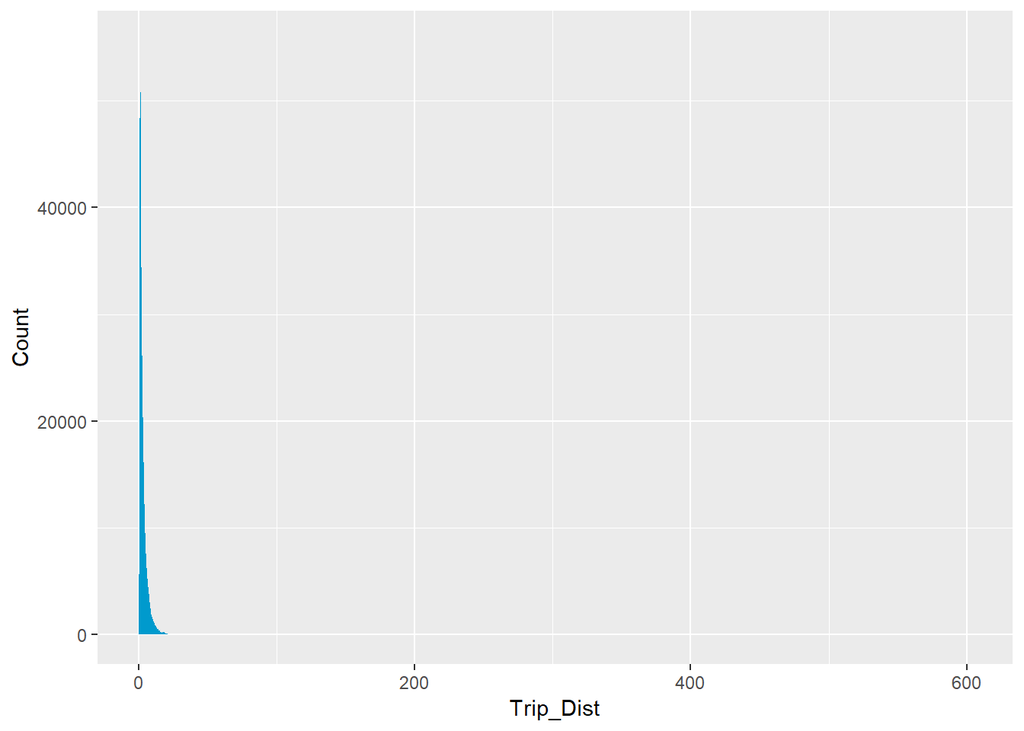

```r
library(ggplot2)

qplot(data1$Trip_distance, geom="histogram", bins = 100, xlab = "Trip_Dist", ylab = "Count",
      binwidth = 0.1, fill = I("deepskyblue3"))
```

```r
#when we plot the histogram without adjusting the xlimits, we can see that the trip distnce is concentrated around 0.
```

As we can see, the trip distances are concentrated around zero. Does that imply New Yorkers use green taxis mainly for shorter trips? We will have a detailed look at the data in the following histogram.

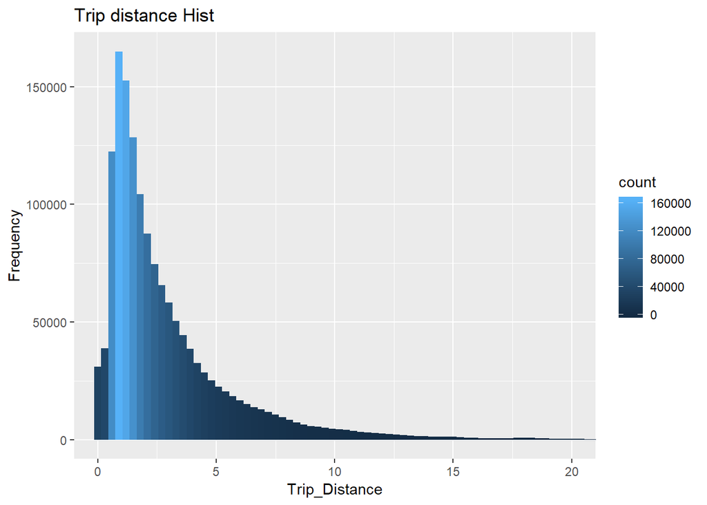

```r
#By Further rifining the plot, we get:

ggplot(data1, aes(x= Trip_distance))+geom_histogram(binwidth = 0.3, aes(fill = ..count..))+
  coord_cartesian(xlim=c(0,20))+
  ggtitle("Trip distance Hist") + xlab("Trip_Distance")+ylab("Frequency")
```

```r
#we can use qplot() instead of ggplot()
```

From the above plot, we can infer that maximum number of trips have a Trip_distance between 0 to 5 miles.

Now, we are going to analyse trip distance grouped by hour of the day. To do the same, please install “lubridate” package using the install.packages() command.

**Question 3**

```r
###########################################################################################
#Question 3
###########################################################################################

library(lubridate)
data1$lpep_pickup_datetime <- ymd_hms(data1$lpep_pickup_datetime, tz = "US/Eastern")
data1$Lpep_dropoff_datetime <- ymd_hms(data1$Lpep_dropoff_datetime, tz = "US/Eastern")
#Time Zone = US? Eastern
#During september, there is no daylight saving adjustment done

##Creating an interval variable in order to ultimately calculate duration
data1$time.interval <- data1$lpep_pickup_datetime%--%data1$Lpep_dropoff_datetime
head(data1$time.interval)
```

```
## [1] 2015-09-01 00:02:34 EDT--2015-09-01 00:02:38 EDT
## [2] 2015-09-01 00:04:20 EDT--2015-09-01 00:04:24 EDT
## [3] 2015-09-01 00:01:50 EDT--2015-09-01 00:04:24 EDT
## [4] 2015-09-01 00:02:36 EDT--2015-09-01 00:06:42 EDT
## [5] 2015-09-01 00:00:14 EDT--2015-09-01 00:04:20 EDT
## [6] 2015-09-01 00:00:39 EDT--2015-09-01 00:05:20 EDT
```

```r
data1$time.duration <- as.duration(data1$time.interval)
summary(data1$time.duration)
```

```
##                                 Min.                              1st Qu.
##                                 "0s"               "371s (~6.18 minutes)"
##                               Median                                 Mean
##              "626s (~10.43 minutes)" "1215.72250793018s (~20.26 minutes)"
##                              3rd Qu.                                 Max.
##             "1036s (~17.27 minutes)"                 "86394s (~24 hours)"
```

```r
#time duration is in seconds
```

Let us use this analysis-ready time data:

```r
data1$DepTime <- hour(data1$lpep_pickup_datetime)


library(dplyr)
```

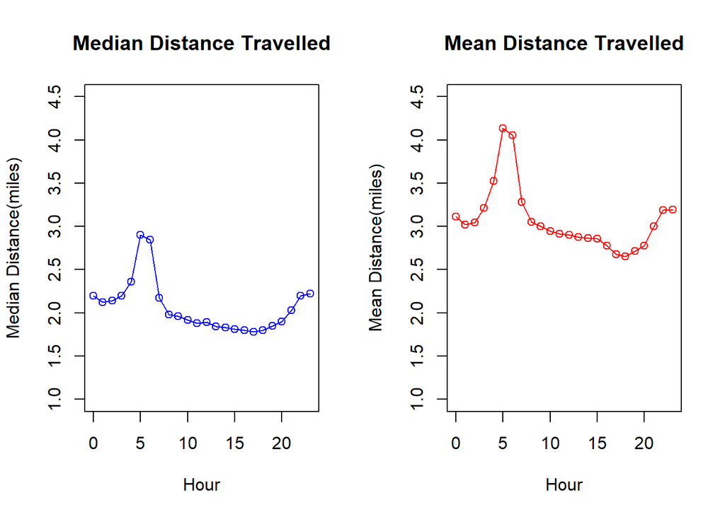

```r
data2<- group_by(data1, DepTime)
dist_by_hour <- as.data.frame(summarize(data2, MeanDist = mean(Trip_distance),
                                        MedianDist = median(Trip_distance) ))
par(mfrow = c(1,2))
plot(dist_by_hour$DepTime, dist_by_hour$MedianDist, type = 'o', col = 'blue',
     main = "Median Distance Travelled", xlab = "Hour", ylab = 'Median Distance(miles)',
     ylim = c(1,4.5))
plot(dist_by_hour$DepTime, dist_by_hour$MeanDist, type = 'o', col = 'red',
     main = "Mean Distance Travelled", xlab = "Hour", ylab = 'Mean Distance(miles)',
     ylim = c(1,4.5))
```

Mean and the median trip distances peak around 5 am and are high in general after 8 pm. During the day, however, the mean/median distances travelled drops. It can be hypothized that New Yorkers take more green cabs during the mornings. Alternately, it is also possible that green cabs are used to travel longer distances in mornings(cab to work, airport pickups/ drops)

Trips terminating at the NYC JFK airport can be analyzed based on RateCodeID = 2 in the dataset. Airport specific analysis can also be done using polygon coordinates pertaining particular airport(s) as will be seen subsequently for question 5. But presently, we will base our analysis on JFK trips.

```r
dat2 <- subset(data1, RateCodeID == 2)
dat_2 <- group_by(dat2, DepTime)
dim(dat_2)
```

```
## [1] 4435   23
```

```r
mean(dat2$Fare_amount)
```

```
## [1] 49.02187
```

```r
median(dat2$Fare_amount)
```

```
## [1] 52
```

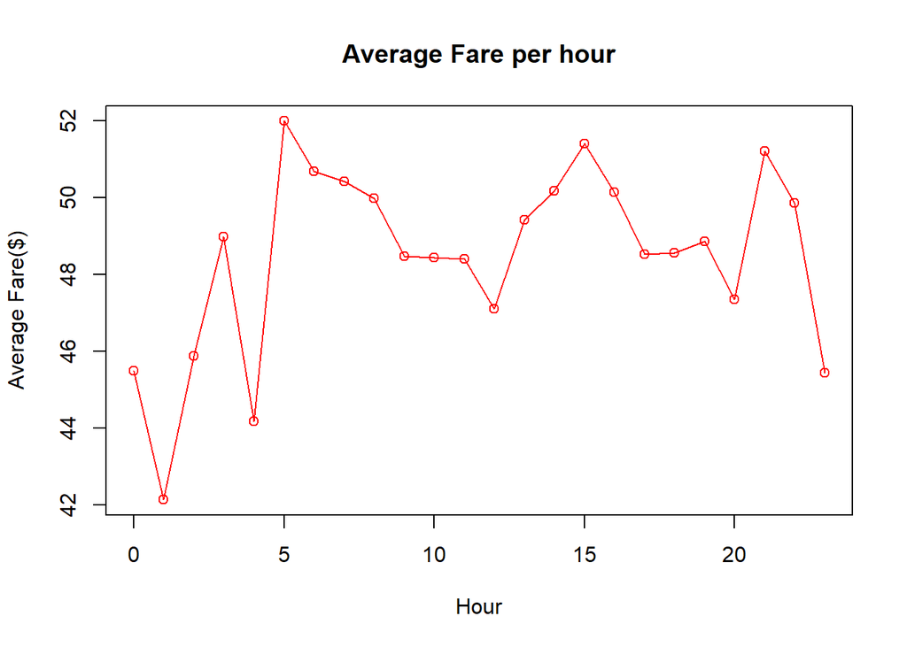

```r
fare_by_hour_jfk <- as.data.frame(summarize(dat_2, Avg_fare = mean(Fare_amount), Median_fare = median(Fare_amount)))



plot(fare_by_hour_jfk$DepTime, fare_by_hour_jfk$Avg_fare, type = 'o', col = 'red',
     main = "Average Fare per hour", xlab = "Hour", ylab = 'Average Fare($)'
     )
```

Mean fare is highest at 5 am and lowest around 1 am. However, the plot of median fare is interesting:

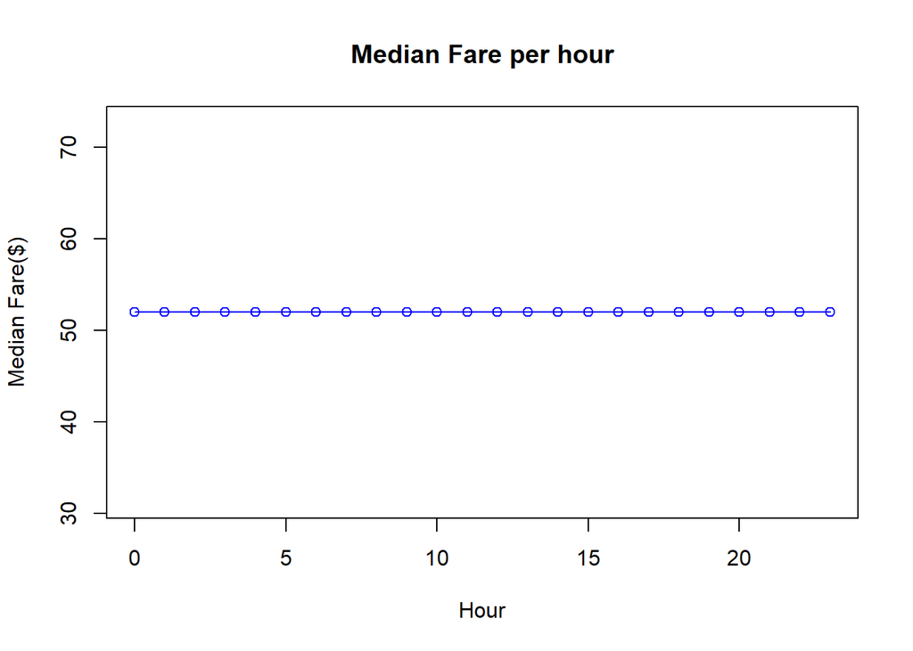

```r
plot(fare_by_hour_jfk$DepTime, fare_by_hour_jfk$Median_fare, type = 'o', col = 'blue',
     main = "Median Fare per hour", xlab = "Hour", ylab = 'Median Fare($)'
     )
```

As seen, interestingly the median fare is constant. Refer output of the following code:

```r
fare_by_hour_jfk
```

```
##    DepTime Avg_fare Median_fare
## 1        0 45.50000          52
## 2        1 42.13793          52
## 3        2 45.88235          52
## 4        3 48.98551          52
## 5        4 44.17204          52
## 6        5 52.00000          52
## 7        6 50.69182          52
## 8        7 50.42424          52
## 9        8 49.98058          52
## 10       9 48.48309          52
## 11      10 48.44878          52
## 12      11 48.40553          52
## 13      12 47.10314          52
## 14      13 49.43210          52
## 15      14 50.18182          52
## 16      15 51.41573          52
## 17      16 50.14837          52
## 18      17 48.53333          52
## 19      18 48.55882          52
## 20      19 48.86207          52
## 21      20 47.35196          52
## 22      21 51.21212          52
## 23      22 49.86885          52
## 24      23 45.44882          52
```

Before we move on to building models and predictions for Tip_percentage, we will be cleaning the data. On clean data, Random Forest is used to extract important variables. Subsequently, a multiple linear regression model is built.